# Clasificación modelo PAM (Partitioning Around Medoids)

Karen Lizeth Velásquez Moná - Ana María Uran González - Daniel Román Ramírez - Daniel Enrique Pinto Restrepo - Carlos Alberto Cerro Espinal

Noviembre de 2019

## Introducción

K-medoids es un método de clustering muy similar a K-means ya que ambos agrupan las observaciones en K clusters, donde K es un valor preestablecido por quien lo estudio. La diferencia es que, en K-medoids, cada cluster está representado por una observación presente en el cluster (medoid), mientras que en K-means cada cluster está representado por su **centroide**, que se corresponde con el promedio de todas las observaciones del cluster pero con ninguna en particular.

Específicamente la definición de **metoid** es el elemento dentro de un cluster cuya distancia (diferencia) promedio entre él y todos los demás elementos del mismo cluster es lo menor posible. Se corresponde con el elemento más central del cluster y por lo tanto puede considerarse como el más representativo. El hecho de utilizar medoids en lugar de centroides hace de K-medoids un método más robusto que K-means, viéndose menos afectado por outliers o ruido. A modo de idea intuitiva puede considerarse como la analogía entre media y mediana.

## Pasos para el desarrollo del método

- Seleccionar K observaciones aleatorias como medoids iniciales.
- Calcular la matriz de distancia entre todas las observaciones
- Asignar cada observación a su medoid más cercano
- Para cada uno de los clusters creados, comprobar si seleccionando otra observación como medoid se consigue reducir la distancia del cluster, si esto ocurre, seleccionar la observación que consigue una mayor reducción como nuevo medoid.
- Si al menos un medoid ha cambiado en el paso 4, volver al paso 3, de lo contrario, se termina el proceso.

## Ventajas y Desventajas

- K - medoids es un método de clustering más robusto que K-means, por lo es más adecuado cuando el set de datos contiene outliers o ruido.
- Necesita que se especifique el número de clusters que se van a crear. Esto puede ser complicado de determinar si no se dispone de información adicional sobre los datos.
- Para sets de datos grandes necesita muchos recursos computacionales. En tal situación se recomienda aplicar el método CLARA.

**Referencia bibliográfica**

https://rpubs.com/Joaquin_AR/310338

## Desarrollo

Directorio de trabajo

```r
setwd("D:/Usuarios/danirorm/Seguros Suramericana, S.A/PROYECTO_MAESTRIA_EAFIT - General/1-R")
```

Partimos de una base con 40 variables y 4,999 observaciones, sobre la cual predominan variables transaccionales haciendo referencia al número de transacciones mensuales realizadas por los clientes desde el mes 6 del año 2017. Durante esta etapa utilizaremos la herramienta R como una opción de exploración de modelos, con el fin de seleccionar los modelos que se ajusten a la solución del problema. A continuación se presenta resumen extraído desde la herramienta sobre la base inicial:

```r
library(dplyr)
```

```r
library(ggplot2)
library(GGally)
library(Hmisc)
library(corrplot)
library(PerformanceAnalytics)
#library(caret)
#library(rlang)
library(readr)
library(cluster)
library(Rtsne)
#Base Inicial
BASE <-read_delim("D:/Usuarios/danirorm/Seguros Suramericana, S.A/PROYECTO_MAESTRIA_EAFIT - General/1-R/Base_modelo.csv",
                     ";", escape_double = FALSE, trim_ws = TRUE)
```

## Exploración de los datos

```r
summary(BASE)
```

```
##    Cliente_Id           Sexo              Estrato      Grupo_valor
##  Min.   :   23206   Length:4999        Min.   :1.000   Length:4999
##  1st Qu.:12254482   Class :character   1st Qu.:4.000   Class :character
##  Median :25172803   Mode  :character   Median :5.000   Mode  :character
##  Mean   :24886674                      Mean   :4.949
##  3rd Qu.:37386930                      3rd Qu.:6.000
##  Max.   :49430008                      Max.   :6.000
##  Rango_ingresos_acum Nivel_estudio      Estado_civil
##  Min.   :4.500e+05   Length:4999        Length:4999
##  1st Qu.:6.900e+06   Class :character   Class :character
##  Median :1.350e+07   Mode  :character   Mode  :character
##  Mean   :1.718e+10
##  3rd Qu.:2.250e+07
##  Max.   :2.168e+13
##  Departamento            Edad           Hijos            Franquicia
##  Length:4999        Min.   : 25.00   Length:4999        Length:4999
##  Class :character   1st Qu.: 34.00   Class :character   Class :character
##  Mode  :character   Median : 44.00   Mode  :character   Mode  :character
##                     Mean   : 45.49
##                     3rd Qu.: 56.00
##                     Max.   :111.00
##     canal              origen          Monto_transado        Reclamos
##  Length:4999        Length:4999        Min.   :       0   Min.   : 2.000
##  Class :character   Class :character   1st Qu.: 3630950   1st Qu.: 2.000
##  Mode  :character   Mode  :character   Median : 9081903   Median : 2.000
##                                        Mean   :15111380   Mean   : 2.508
##                                        3rd Qu.:19445268   3rd Qu.: 3.000
##                                        Max.   :98744657   Max.   :14.000
##  cnt_trx_201706    cnt_trx_201707    cnt_trx_201708   cnt_trx_201709
##  Min.   :  0.000   Min.   :  0.000   Min.   :  0.00   Min.   :  0.000
##  1st Qu.:  2.000   1st Qu.:  2.000   1st Qu.:  2.00   1st Qu.:  1.000
##  Median :  4.000   Median :  5.000   Median :  5.00   Median :  4.000
##  Mean   :  6.663   Mean   :  9.477   Mean   :  8.84   Mean   :  8.507
##  3rd Qu.:  8.000   3rd Qu.: 12.000   3rd Qu.: 11.00   3rd Qu.: 11.000
##  Max.   :101.000   Max.   :143.000   Max.   :182.00   Max.   :202.000
##  cnt_trx_201710   cnt_trx_201711    cnt_trx_201712    cnt_trx_201801
##  Min.   :  0.00   Min.   :  0.000   Min.   :  0.000   Min.   :  0.00
##  1st Qu.:  1.00   1st Qu.:  1.000   1st Qu.:  1.000   1st Qu.:  0.00
##  Median :  4.00   Median :  4.000   Median :  4.000   Median :  3.00
##  Mean   :  8.48   Mean   :  8.397   Mean   :  8.175   Mean   :  7.43
```

[output cut: 22 more lines]

```
##  Max.   :221.000   Max.   :207.000   Max.   :124.000   Max.   :111.000
##  cnt_trx_201902    cnt_trx_201903    cnt_trx_201904    cnt_trx_201905
##  Min.   :  0.000   Min.   :  0.000   Min.   :  0.000   Min.   :  0.000
##  1st Qu.:  0.000   1st Qu.:  0.000   1st Qu.:  0.000   1st Qu.:  0.000
##  Median :  0.000   Median :  0.000   Median :  0.000   Median :  0.000
##  Mean   :  4.731   Mean   :  4.532   Mean   :  4.595   Mean   :  4.833
##  3rd Qu.:  5.000   3rd Qu.:  4.000   3rd Qu.:  4.000   3rd Qu.:  4.000
##  Max.   :135.000   Max.   :120.000   Max.   :158.000   Max.   :185.000
##  cnt_trx_201906      Total_trx
##  Min.   :  0.000   Min.   :   0.0
##  1st Qu.:  0.000   1st Qu.:  40.0
##  Median :  0.000   Median :  92.0
##  Mean   :  4.324   Mean   : 166.6
##  3rd Qu.:  4.000   3rd Qu.: 200.0
##  Max.   :142.000   Max.   :3293.0
```

## Funciones para el modelo

```r
###Creacion de funcion

# enumerate linear combinations
enumLC <- function(object, ...) UseMethod("enumLC")

#' @export
enumLC.default <- function(object, ...)
{
  # there doesn't seem to be a reasonable default, so
  # we'll throw an error
  stop(paste('enumLC does not support ', class(object), 'objects'))
}

enumLC.matrix <- function(object, ...)
{
  # factor the matrix using QR decomposition and then process it
  internalEnumLC(qr(object))
}

enumLC.lm <- function(object, ...)
{
  # extract the QR decomposition and the process it
  internalEnumLC(object$qr)
}

#' @importFrom stats lm
enumLC.formula <- function(object, ...)
{
  # create an lm fit object from the formula, and then call
  # appropriate enumLC method
  enumLC(lm(object))
}

# this function does the actual work for all of the enumLC methods
internalEnumLC <- function(qrObj, ...)
{
  R <- qr.R(qrObj)                     # extract R matrix
  numColumns <- dim(R)[2]              # number of columns in R
  rank <- qrObj$rank                   # number of independent columns
  pivot <- qrObj$pivot                 # get the pivot vector

  if (is.null(numColumns) || rank == numColumns)
  {
    list()                            # there are no linear combinations
  } else {
    p1 <- 1:rank
    X <- R[p1, p1]                    # extract the independent columns
    Y <- R[p1, -p1, drop = FALSE]     # extract the dependent columns
    b <- qr(X)                        # factor the independent columns
    b <- qr.coef(b, Y)                # get regression coefficients of
    # the dependent columns
    b[abs(b) < 1e-6] <- 0             # zap small values

    # generate a list with one element for each dependent column
    lapply(1:dim(Y)[2],
           function(i) c(pivot[rank + i], pivot[which(b[,i] != 0)]))
  }
}

findLinearCombos <- function(x)
{
  if(!is.matrix(x)) x <- as.matrix(x)
  lcList <- enumLC(x)
  initialList <- lcList
  badList <- NULL
  if(length(lcList) > 0)
  {
    continue <- TRUE
    while(continue)
    {
      # keep removing linear dependencies until it resolves
      tmp <- unlist(lapply(lcList, function(x) x[1]))
      tmp <- unique(tmp[!is.na(tmp)])
      badList <- unique(c(tmp, badList))
      lcList <- enumLC(x[,-badList, drop = FALSE])
      continue <- (length(lcList) > 0)
    }
  } else badList <- NULL
  list(linearCombos = initialList, remove = badList)
}
```

**Construcción del modelo**

Se extrae los ID de la base, y queda guardado en BASE_ID y se trabaja la base sin el ID.

```r
#Extraemos el ID
BASE_ID <- BASE[1]

#Base solo con variables

BASE <- BASE[,-1]

BASE$Estrato <- as.factor(BASE$Estrato)
BASE$Edad <- as.factor(BASE$Edad)

summary(BASE)
```

```
##      Sexo           Estrato  Grupo_valor        Rango_ingresos_acum
##  Length:4999        1:   2   Length:4999        Min.   :4.500e+05
##  Class :character   2:   3   Class :character   1st Qu.:6.900e+06
##  Mode  :character   3:   5   Mode  :character   Median :1.350e+07
##                     4:1789                      Mean   :1.718e+10
##                     5:1638                      3rd Qu.:2.250e+07
##                     6:1562                      Max.   :2.168e+13
##
##  Nivel_estudio      Estado_civil       Departamento            Edad
##  Length:4999        Length:4999        Length:4999        35     : 183
##  Class :character   Class :character   Class :character   31     : 164
##  Mode  :character   Mode  :character   Mode  :character   26     : 156
##                                                           29     : 155
##                                                           34     : 155
##                                                           30     : 153
##                                                           (Other):4033
##     Hijos            Franquicia           canal
##  Length:4999        Length:4999        Length:4999
##  Class :character   Class :character   Class :character
##  Mode  :character   Mode  :character   Mode  :character
##
##
##
##
##     origen          Monto_transado        Reclamos      cnt_trx_201706
##  Length:4999        Min.   :       0   Min.   : 2.000   Min.   :  0.000
##  Class :character   1st Qu.: 3630950   1st Qu.: 2.000   1st Qu.:  2.000
##  Mode  :character   Median : 9081903   Median : 2.000   Median :  4.000
##                     Mean   :15111380   Mean   : 2.508   Mean   :  6.663
##                     3rd Qu.:19445268   3rd Qu.: 3.000   3rd Qu.:  8.000
##                     Max.   :98744657   Max.   :14.000   Max.   :101.000
##
##  cnt_trx_201707    cnt_trx_201708   cnt_trx_201709    cnt_trx_201710
##  Min.   :  0.000   Min.   :  0.00   Min.   :  0.000   Min.   :  0.00
##  1st Qu.:  2.000   1st Qu.:  2.00   1st Qu.:  1.000   1st Qu.:  1.00
##  Median :  5.000   Median :  5.00   Median :  4.000   Median :  4.00
##  Mean   :  9.477   Mean   :  8.84   Mean   :  8.507   Mean   :  8.48
##  3rd Qu.: 12.000   3rd Qu.: 11.00   3rd Qu.: 11.000   3rd Qu.: 10.00
##  Max.   :143.000   Max.   :182.00   Max.   :202.000   Max.   :220.00
##
```

[output cut: 33 more lines]

```
##  Min.   :  0.000   Min.   :  0.000   Min.   :  0.000   Min.   :  0.000
##  1st Qu.:  0.000   1st Qu.:  0.000   1st Qu.:  0.000   1st Qu.:  0.000
##  Median :  0.000   Median :  0.000   Median :  0.000   Median :  0.000
##  Mean   :  4.532   Mean   :  4.595   Mean   :  4.833   Mean   :  4.324
##  3rd Qu.:  4.000   3rd Qu.:  4.000   3rd Qu.:  4.000   3rd Qu.:  4.000
##  Max.   :120.000   Max.   :158.000   Max.   :185.000   Max.   :142.000
##
##    Total_trx
##  Min.   :   0.0
##  1st Qu.:  40.0
##  Median :  92.0
##  Mean   : 166.6
##  3rd Qu.: 200.0
##  Max.   :3293.0
##
```

**Transformación de los datos**

```r
BASE_num <- BASE[sapply(BASE, is.numeric)]
BASE_cat <- BASE[sapply(BASE, is.factor)]
```

```r
for(i in 1:ncol(BASE_num)){
  BASE_num[,i] = ((BASE_num[,i])-min(BASE_num[,i])/(max(BASE_num[,i]))-(min(BASE_num[,i])))
}
```

## Unificación de variables

A través de la función findLinearCombos se busca encontrar la colinealidad entre las diferentes variables. Correlación entre las variables que hacen referencias a la cantidad de transacciones

```r
comboinfo <- findLinearCombos(BASE_num)
comboinfo
```

```
## $linearCombos
## $linearCombos[[1]]
##  [1] 29  4  5  6  7  8  9 10 11 12 13 14 15 16 17 18 19 20 21 22 23 24 25
## [24] 26 27 28
##
##
## $remove
## [1] 29
```

```r
#View(BASE)
N_BASE_num <- BASE_num[, -comboinfo$remove]
comboinfo <- findLinearCombos(N_BASE_num)
```

Con el fin de encontrar un modelo indicado se prueba el modelo PAM (Partitioning Around Medoids), todos los modelos de segmentación tratan de resolver el mismo problema de minimizar una diferencia de distancias calculadas, este modelo es muy parecido al algoritmo de k-means la diferencia principal es que PAM está calculado con medioides mientras que K-medias lo hace sobre centroides.

## Partitioning Around Medoids

- Se calcula la distancia de las observaciones con la función Daisy:

Es una función que se utiliza cuando se tienen variables mixtas (numéricas y categóricas), donde la métrica con la cual se obtienen las distancias es “gower”.

- Se minimiza una distancia

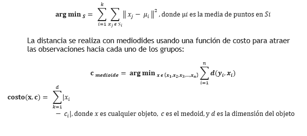

```r
# dist_grid<- daisy(BASE,metric = "gower")
# d_matrix <- as.matrix(dist_grid)
#
# sil_width <- c(NA)
#
# for(i in 2:15){
#   pam_fit <- pam(dist_grid,
#                  diss = TRUE,
#                  k = i)
#   sil_width[i] <- pam_fit$silinfo$avg.width
# }
#
# plot(1:15, sil_width,
#      xlab = "Número de cluster",
#      ylab = "Silueta")
# lines(1:15,sil_width)
```

**Seleccionando el k**

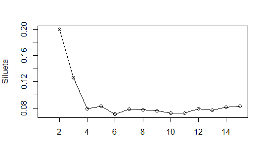

Seleccionando el k óptimo

```r
# clusters_d <- hclust(dist_grid,method = "ward.D2")
# cluster <- cutree(clusters_d, k=4)
#
# BASE_cluster <- cbind(BASE, cluster)
#
# pam_results <- BASE_cluster%>%
#   dplyr::select(-cluster)%>%
#   mutate(cluster=pam_fit$clustering)%>%
#   group_by(cluster)%>%
#   do(the_summary = summary(.))
#
#
# pam_results$the_summary
```

## Gráfica del modelo

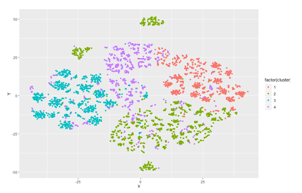

```r
# g1 <- ggplot(aes(x=X,y=Y),data=BASE_cluster_full)
# g1+geom_point(aes(color=factor(cluster)))+
#   ggtitle("")
```